# - FNU Andria Grace

## Introduction

### An exploratory data analysis (EDA) of a targeted marketing dataset. The analysis aims to understand the data structure, identify patterns, and uncover relationships between variables that can inform marketing strategies.

## Importing Libraries which are required for the project

### The analysis begins by importing the necessary Python libraries:

```python
import pandas as pd
import numpy as np
import matplotlib.pyplot as plt
import seaborn as sns
import warnings
warnings.filterwarnings('ignore')
```

### The dataset was read from a CSV file and initial column names were assigned for clarity:

## Reading Dataset

```python
# Specify the file path
file_path = 'C:/Users/acer/Downloads/hist.csv'

# Read the CSV file into a DataFrame
df = pd.read_csv(file_path, header=None)

df.head(10)
```

|  | 0 | 1 | 2 | 3 | 4 | 5 | 6 |
| --- | --- | --- | --- | --- | --- | --- | --- |
| 0 | 1 | 1 | B | 2 | M | 1 | 1 |
| 1 | 1 | 2 | A | 38 | F | 2 | 0 |
| 2 | 1 | 3 | C | 46 | M | 3 | 0 |
| 3 | 1 | 4 | B | 35 | M | 4 | 0 |
| 4 | 1 | 5 | B | 22 | M | 5 | 1 |
| 5 | 1 | 6 | B | 39 | F | 6 | 1 |
| 6 | 1 | 7 | A | 28 | M | 7 | 1 |
| 7 | 1 | 8 | A | 46 | M | 8 | 0 |
| 8 | 1 | 9 | C | 32 | M | 9 | 1 |
| 9 | 1 | 10 | C | 25 | M | 10 | 1 |

### Adding columns names

```python
# Assign column names
df.columns = ["week", "id.no", "attribute", "state", "sex", "campaign", "response"]

# Display the first 5 rows
df.head()
```

|  | week | id.no | attribute | state | sex | campaign | response |
| --- | --- | --- | --- | --- | --- | --- | --- |
| 0 | 1 | 1 | B | 2 | M | 1 | 1 |
| 1 | 1 | 2 | A | 38 | F | 2 | 0 |
| 2 | 1 | 3 | C | 46 | M | 3 | 0 |
| 3 | 1 | 4 | B | 35 | M | 4 | 0 |
| 4 | 1 | 5 | B | 22 | M | 5 | 1 |

# Understanding the data

## The dataset contains 7 columns with mixed data types. Here is an overview of the dataset structure and contents:

```python
# Get Basic Information
df.info()
```

```
<class 'pandas.core.frame.DataFrame'>
RangeIndex: 260000 entries, 0 to 259999
Data columns (total 7 columns):
 #   Column     Non-Null Count   Dtype
---  ------     --------------   -----
 0   week       260000 non-null  int64
 1   id.no      260000 non-null  int64
 2   attribute  260000 non-null  object
 3   state      260000 non-null  int64
 4   sex        260000 non-null  object
 5   campaign   260000 non-null  int64
 6   response   260000 non-null  int64
dtypes: int64(5), object(2)
memory usage: 13.9+ MB
```

```python
df.columns
```

```
Index(['week', 'id.no', 'attribute', 'state', 'sex', 'campaign', 'response'], dtype='object')
```

```python
# Statistical Summary
df.describe()
```

|  | week | id.no | state | campaign | response |
| --- | --- | --- | --- | --- | --- |
| count | 260000.000000 | 260000.000000 | 260000.000000 | 260000.000000 | 260000.000000 |
| mean | 13.500000 | 5211.700000 | 25.293800 | 5.500000 | 0.424454 |
| std | 7.500014 | 3307.146485 | 14.425272 | 2.872287 | 0.494261 |
| min | 1.000000 | 1.000000 | 1.000000 | 1.000000 | 0.000000 |
| 25% | 7.000000 | 2500.750000 | 13.000000 | 3.000000 | 0.000000 |
| 50% | 13.500000 | 5000.500000 | 25.000000 | 5.500000 | 0.000000 |
| 75% | 20.000000 | 7500.250000 | 38.000000 | 8.000000 | 1.000000 |
| max | 26.000000 | 13200.000000 | 50.000000 | 10.000000 | 1.000000 |

```python
#checking datatypes
df.dtypes
```

```
week          int64
id.no         int64
attribute    object
state         int64
sex          object
campaign      int64
response      int64
dtype: object
```

## To ensure data quality, checks for duplicates and missing values were performed:

```python
#Analysing rows and columns to find the number of rows and columns in a data set
df.shape
```

```
(260000, 7)
```

```python
#lets check whether data is duplicated or not
df.duplicated().sum()
```

```
0
```

```python
df.isnull().sum()
```

```
week         0
id.no        0
attribute    0
state        0
sex          0
campaign     0
response     0
dtype: int64
```

```python
#checking for missing values
df.isnull().sum().sort_values(ascending=False)
```

```
week         0
id.no        0
attribute    0
state        0
sex          0
campaign     0
response     0
dtype: int64
```

# Exploratory Data Analysis

# Univariate Analysis

### Univariate analysis focuses on examining each variable individually. This type of analysis helps in understanding the distribution, central tendency, and dispersion of the data for a single variable.

```python
print(df.columns)
```

```
Index(['week', 'id.no', 'attribute', 'state', 'sex', 'campaign', 'response'], dtype='object')
```

```python
# Summary statistics for the DataFrame
df.describe()
```

|  | week | id.no | state | campaign | response |
| --- | --- | --- | --- | --- | --- |
| count | 260000.000000 | 260000.000000 | 260000.000000 | 260000.000000 | 260000.000000 |
| mean | 13.500000 | 5211.700000 | 25.293800 | 5.500000 | 0.424454 |
| std | 7.500014 | 3307.146485 | 14.425272 | 2.872287 | 0.494261 |
| min | 1.000000 | 1.000000 | 1.000000 | 1.000000 | 0.000000 |
| 25% | 7.000000 | 2500.750000 | 13.000000 | 3.000000 | 0.000000 |
| 50% | 13.500000 | 5000.500000 | 25.000000 | 5.500000 | 0.000000 |
| 75% | 20.000000 | 7500.250000 | 38.000000 | 8.000000 | 1.000000 |
| max | 26.000000 | 13200.000000 | 50.000000 | 10.000000 | 1.000000 |

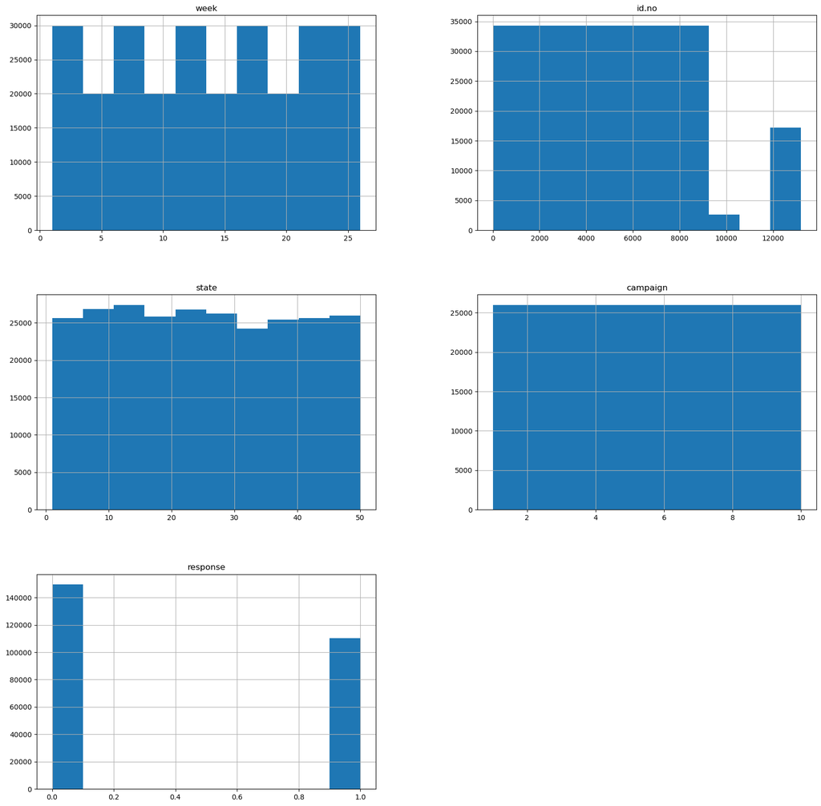

```python
df.hist(figsize=(20,20))
# display histogram
plt.show()
```

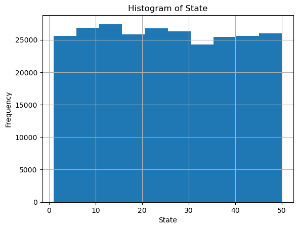

```python
# Histogram of a numerical column
df['state'].hist()
plt.title('Histogram of State')
plt.xlabel('State')
plt.ylabel('Frequency')
plt.show()
```

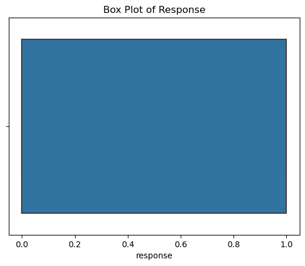

```python
# Box plot of a numerical column
sns.boxplot(x=df['response'])
plt.title('Box Plot of Response')
plt.show()
```

```python
# Frequency count for a categorical column
print(df['state'].value_counts())
```

```
8     5824
25    5772
29    5746
13    5746
15    5694
6     5616
1     5538
48    5512
47    5486
12    5486
24    5434
21    5408
43    5408
11    5408
9     5382
```

[output cut: 36 more lines]

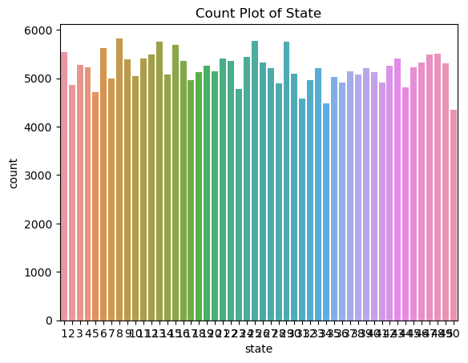

```python
# Count plot for a categorical column
sns.countplot(x='state', data=df)
plt.title('Count Plot of State')
plt.show()
```

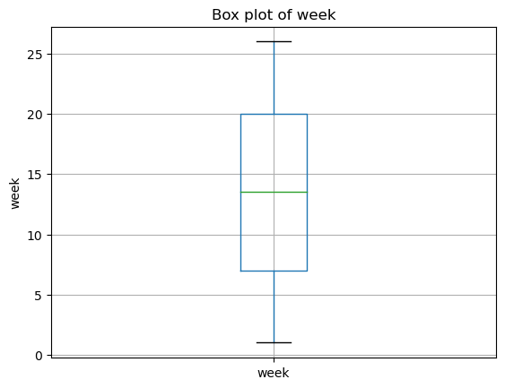

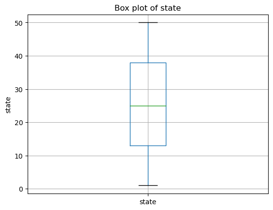

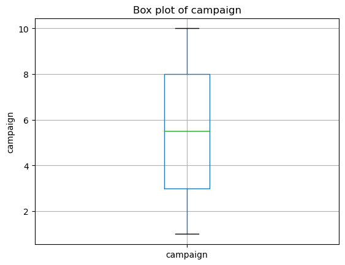

```python
# List of numerical variables
numerical_variables = ['week', 'state', 'campaign']

# Creating box plots for numerical variables
for variable in numerical_variables:
    df.boxplot(column=variable)
    plt.title(f'Box plot of {variable}')
    plt.ylabel(variable)
    plt.show()
```

# Bivariate Analysis

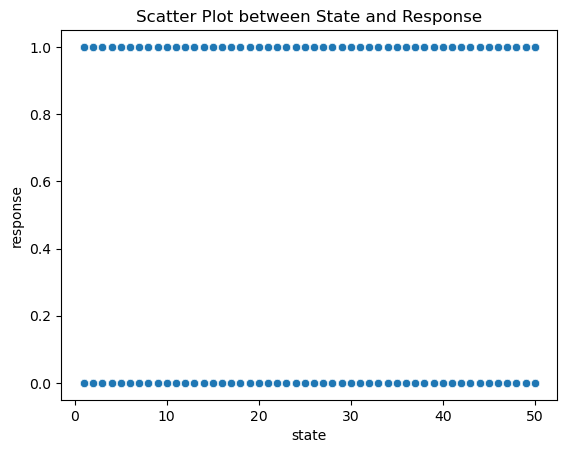

```python
# Scatter plot between two numerical columns
sns.scatterplot(x='state', y='response', data=df)
plt.title('Scatter Plot between State and Response')
plt.show()
```

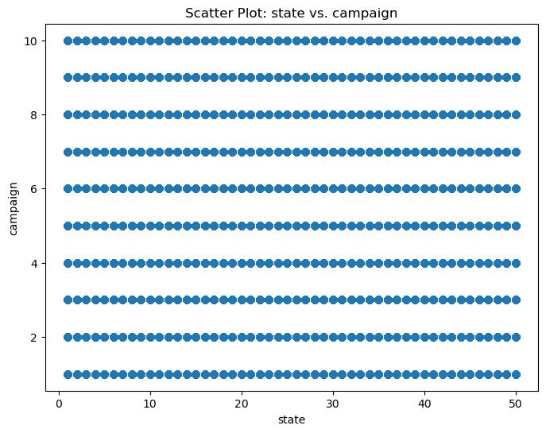

```python
#  Scatter Plot
plt.figure(figsize=(8, 6))
plt.scatter(df['state'], df['campaign'])
plt.title('Scatter Plot: state vs. campaign')
plt.xlabel('state')
plt.ylabel('campaign')
plt.show()
```

```python
# Correlation matrix
corr_matrix = df.corr()
print(corr_matrix)
```

```
                  week         id.no         state      campaign  response
week      1.000000e+00 -5.376100e-15 -1.787635e-14  3.558089e-15  0.185616
id.no    -5.376100e-15  1.000000e+00 -2.967443e-03  8.097987e-06 -0.002551
state    -1.787635e-14 -2.967443e-03  1.000000e+00  2.300265e-04  0.001049
campaign  3.558089e-15  8.097987e-06  2.300265e-04  1.000000e+00 -0.020113
response  1.856161e-01 -2.550602e-03  1.049126e-03 -2.011325e-02  1.000000
```

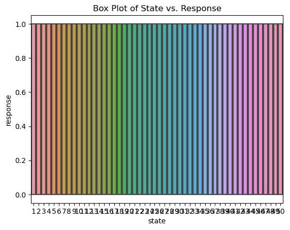

```python
# Box plot between a categorical column and a numerical column
sns.boxplot(x='state', y='response', data=df)
plt.title('Box Plot of State vs. Response')
plt.show()
```